# Computing and Information Systems Graduates: Employment Outcomes Analysis

Data Analysis Portfolio Project

2026-05-27

## 1. Introduction

This project analyses Australian Computing and Information Systems (CIS) graduate outcomes using real public summary data from the QILT Graduate Outcomes Survey - Longitudinal (GOS-L) 2025 National Report Tables.

The analysis is designed as a data analyst portfolio project. It focuses on practical questions that a university, student advisor, or education policy team might ask: how strong are CIS graduate outcomes, how do they compare with other study areas, and where are salary gaps still visible?

### Key Metrics

```
##                                  Metric      Result
## 1 Medium-term full-time employment rate         91%
## 2   Medium-term overall employment rate         92%
## 3              Short-term median salary  AUD 69,100
## 4             Medium-term median salary   AUD 1e+05
## 5                         Salary growth  AUD 30,900
## 6        Male medium-term median salary AUD 103,000
## 7      Female medium-term median salary  AUD 94,000
## 8                        Gender pay gap        8.7%
```

### Research Questions

1. How do CIS graduates compare with other study areas in employment and salary outcomes?
2. What is the gender pay gap for CIS graduates compared with other study areas?
3. Which universities show strong medium-term employment and salary outcomes?

## 2. Data Source and Wrangling

The data source is the QILT GOS-L 2025 National Report Tables. GOS-L surveys graduates around three years after course completion and reports medium-term graduate outcomes.

The project uses the following extracted tables:

- study-area employment and salary summary;
- study-area and gender employment and salary summary;
- university-level medium-term full-time employment rates;
- university-level medium-term median salaries.

Because the public file is an Excel workbook with many report sheets, a small Python script extracts selected sheets into clean CSV files. The main analysis is then completed in R.

Data checking included:

- checking employment rates are between 0 and 100;
- checking salaries are positive and within a reasonable range;
- removing duplicate rows;
- creating CIS and STEM-related flags;
- calculating short-term to medium-term employment and salary growth;
- calculating gender pay gap by study area.

This workflow turns a multi-sheet public Excel report into analysis-ready CSV files, which makes the project easier to reproduce and review.

```
##   study_areas cis_medium_term_full_time_employment
## 1          21                                   91
##   cis_medium_term_overall_employment cis_medium_term_salary_aud
## 1                                 92                      1e+05
##   cis_gender_pay_gap
## 1             0.0874
```

## 3. Employment Outcomes

### 3.1 Full-time Employment

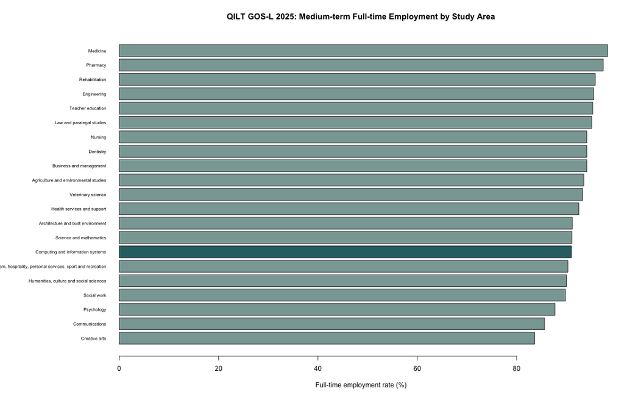

### 3.2 Overall Employment

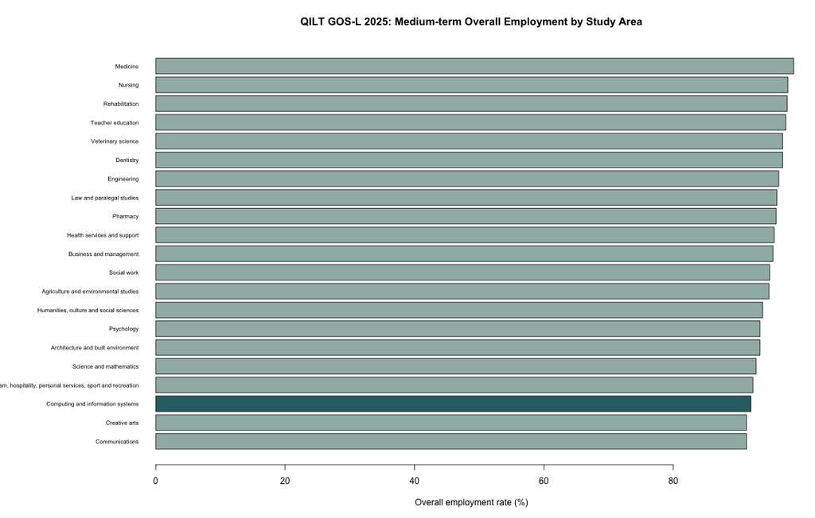

```
##                  field_of_education                                 source
## 5 Computing and information systems QILT GOS-L 2025 National Report Tables
##   survey_year                 cohort short_term_full_time_employment_rate
## 5        2025 Domestic undergraduate                                 77.5
##   medium_term_full_time_employment_rate short_term_overall_employment_rate
## 5                                    91                               84.2
##   medium_term_overall_employment_rate
## 5                                  92
##   short_term_labour_force_participation_rate
## 5                                         95
##   medium_term_labour_force_participation_rate short_term_median_salary_aud
## 5                                          95                        69100
##   medium_term_median_salary_aud is_cis is_stem_related
## 5                         1e+05    Yes             Yes
##   full_time_employment_growth overall_employment_growth salary_growth
## 5                        13.5                       7.8         30900
##   salary_growth_rate high_medium_salary male_medium_salary_aud
## 5           0.447178                Yes                 103000
##   female_medium_salary_aud gender_pay_gap
## 5                    94000     0.08737864
```

The QILT 2025 data shows that CIS undergraduates had a medium-term full-time employment rate of 91% and a medium-term overall employment rate of 92%. Their medium-term median salary was 1e+05 AUD.

## 4. Salary Outcomes

### 4.1 Medium-term Median Salary

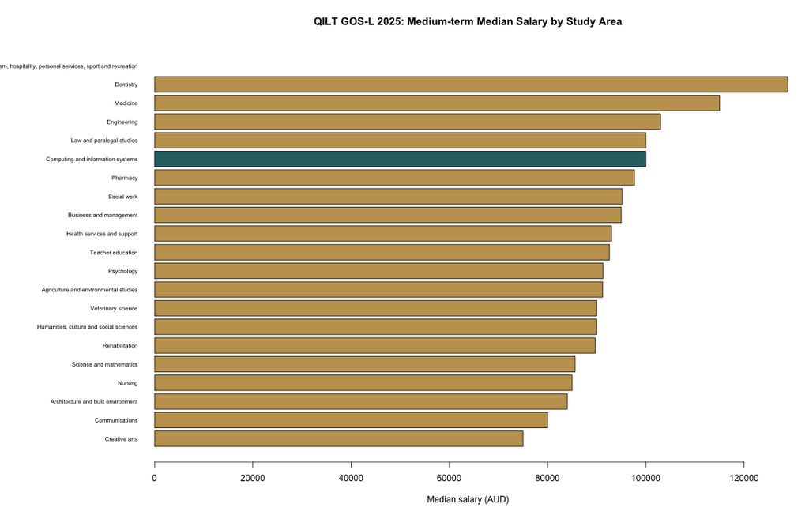

### 4.2 Salary Growth

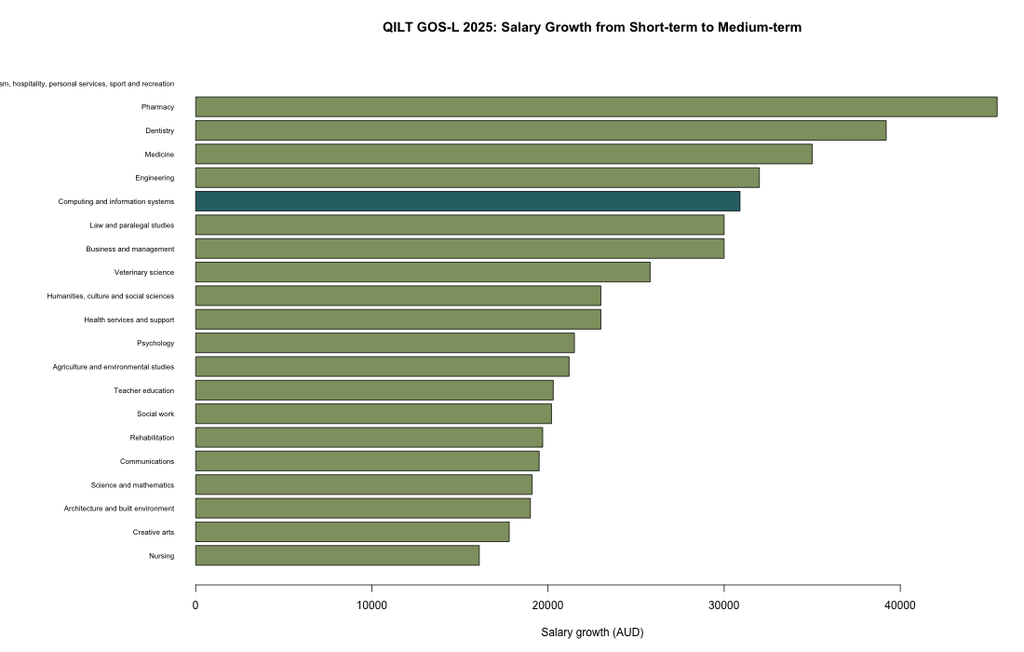

### 4.3 Employment and Salary Relationship

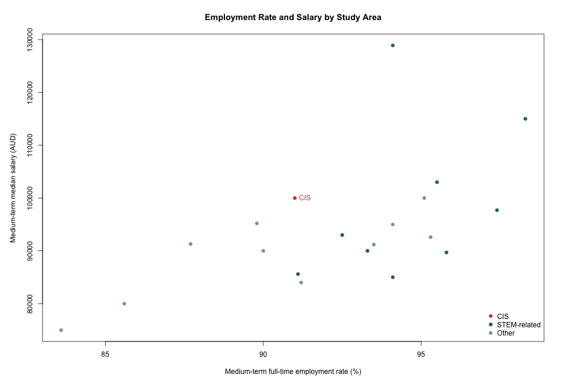

These salary charts show how CIS compares with other study areas. CIS has both strong medium-term employment and a high medium-term median salary, which makes it one of the stronger outcomes in the QILT summary data.

## 5. Gender Pay Gap

The gender pay gap is calculated as:

```
(Male medium-term median salary - Female medium-term median salary) / Male medium-term median salary
```

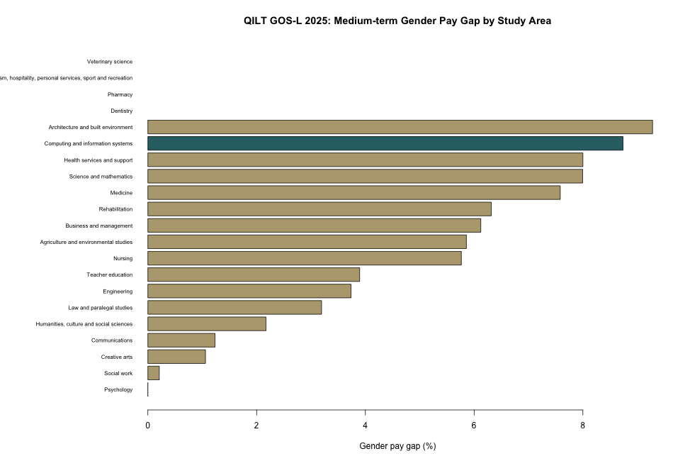

```
##                  field_of_education male_medium_salary_aud
## 5 Computing and information systems                 103000
##   female_medium_salary_aud gender_pay_gap
## 5                    94000     0.08737864
```

For CIS, male graduates had a medium-term median salary of 103,000 AUD, while female graduates had a medium-term median salary of 94,000 AUD. The calculated CIS gender pay gap is about 8.7%.

### 5.1 STEM-related Gender Pay Gap

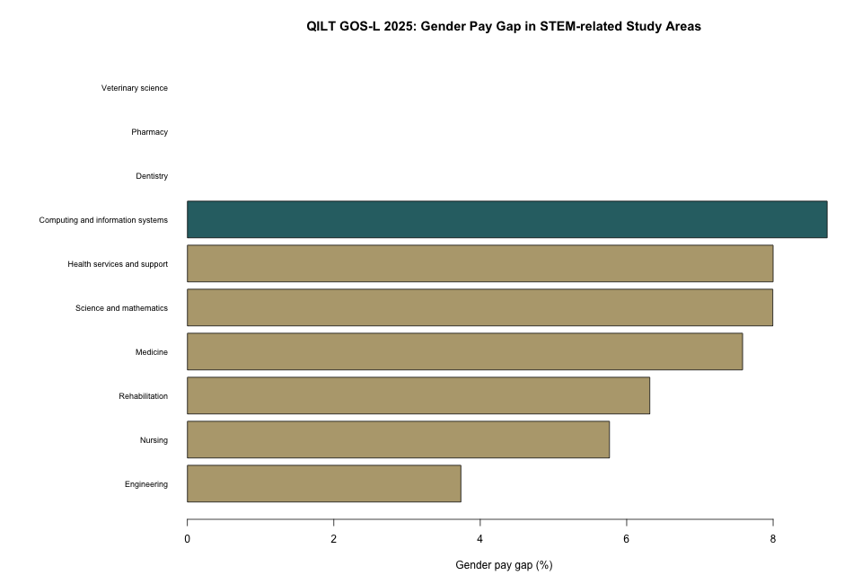

The STEM-related comparison helps show whether the CIS gender pay gap is unusual or part of a wider STEM pattern. This is useful because the original project topic also discusses gender differences in technology-related fields.

## 6. Institutional Outcomes

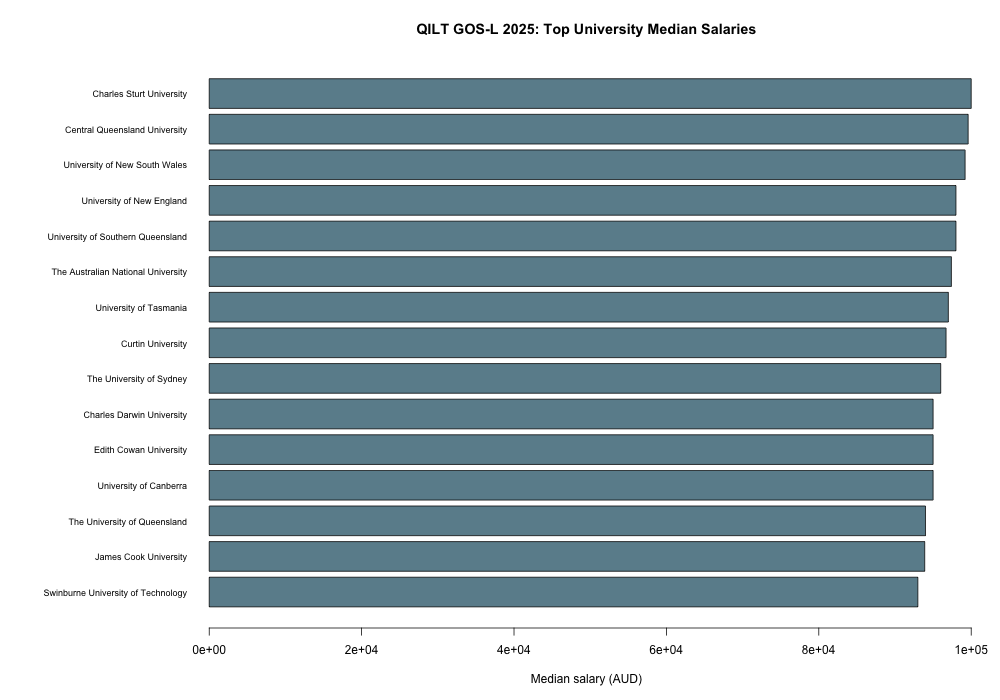

```
##                                    source survey_year
## 1  QILT GOS-L 2025 National Report Tables        2025
## 2  QILT GOS-L 2025 National Report Tables        2025
## 3  QILT GOS-L 2025 National Report Tables        2025
## 4  QILT GOS-L 2025 National Report Tables        2025
## 5  QILT GOS-L 2025 National Report Tables        2025
## 6  QILT GOS-L 2025 National Report Tables        2025
## 7  QILT GOS-L 2025 National Report Tables        2025
## 8  QILT GOS-L 2025 National Report Tables        2025
## 9  QILT GOS-L 2025 National Report Tables        2025
## 10 QILT GOS-L 2025 National Report Tables        2025
##                                 cohort                        institution
## 1  Domestic undergraduate universities           Charles Sturt University
## 2  Domestic undergraduate universities      Central Queensland University
## 3  Domestic undergraduate universities      University of New South Wales
```

[output cut: 51 more lines]

The institutional table compares universities by medium-term full-time employment rate and median salary. Since the public workbook provides university-level summary values, this section focuses on descriptive comparison rather than individual-level modelling.

## 7. Modelling

This project uses two simple models:

- linear regression to explain medium-term median salary across study areas;
- decision tree to classify whether a study area has above-median medium-term salary.

These models are exploratory. They are used to understand relationships in aggregated data, not to predict individual graduate outcomes.

```
##                             model
## 1  linear_regression_salary_model
## 2 decision_tree_high_salary_model
##                                                 task            metric
## 1                  Predict medium-term median salary              RMSE
## 2 Classify whether field has high medium-term salary Training accuracy
##       value
## 1 3803.5900
## 2    0.5294
```

The salary regression model is saved as:

```
outputs/models/salary_regression_model.rds
```

The high-salary decision tree model is saved as:

```
outputs/models/best_employment_model.rds
```

### Feature Importance

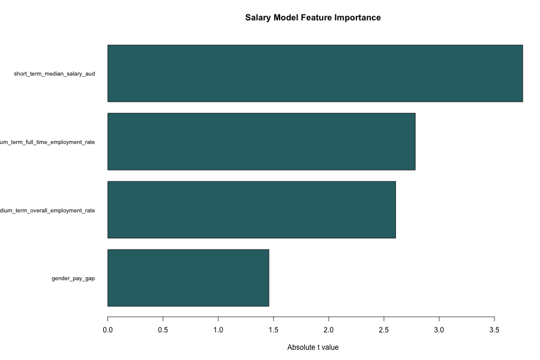

```
##                                 feature importance
## 1          short_term_median_salary_aud   3.756162
## 2 medium_term_full_time_employment_rate   2.783515
## 3   medium_term_overall_employment_rate   2.606563
## 4                        gender_pay_gap   1.458300
```

## 8. Correlation Analysis

```
##                                         short_term_full_time_employment_rate
## 1  short_term_full_time_employment_rate                               1.0000
## 2 medium_term_full_time_employment_rate                               0.8605
## 3    short_term_overall_employment_rate                               0.6943
## 4   medium_term_overall_employment_rate                               0.8563
## 5          short_term_median_salary_aud                               0.3069
## 6         medium_term_median_salary_aud                               0.5793
## 7                         salary_growth                               0.5694
## 8                        gender_pay_gap                               0.4270
##   medium_term_full_time_employment_rate short_term_overall_employment_rate
## 1                                0.8605                             0.6943
## 2                                1.0000                             0.6809
## 3                                0.6809                             1.0000
## 4                                0.8558                             0.6553
## 5                                0.3266                             0.0151
```

[output cut: 21 more lines]

The correlation table shows relationships between employment rates, salary growth, median salary, and gender pay gap across study areas.

## 9. Conclusion

Using real QILT GOS-L 2025 public summary data, CIS graduates show strong medium-term employment and salary outcomes. CIS has a medium-term full-time employment rate above 90% and a median salary of 100,000 AUD, which places it among the stronger study areas in the dataset.

The gender pay gap remains visible. In CIS, the male medium-term median salary is higher than the female medium-term median salary, producing a gender pay gap of around 8.7%. This suggests that pay equity remains an important issue even in a high-demand technology-related field.

The university-level tables show that several institutions report strong medium-term employment and salary outcomes. However, because the public data is aggregated, the results should be interpreted as descriptive findings rather than individual-level causal evidence.

## 10. Limitations

This project uses official public summary tables, not confidential person-level survey records. Because of this, the project cannot model individual graduate outcomes such as personal GPA, internship history, or job search behaviour. The analysis is still useful for comparing study areas and institutions, but it should not be presented as a causal analysis.

## 11. References

Quality Indicators for Learning and Teaching. (2025). Graduate Outcomes Survey - Longitudinal National Report Tables.

Quality Indicators for Learning and Teaching. Graduate Outcomes Survey - Longitudinal. https://qilt.edu.au/surveys/graduate-outcomes-survey---longitudinal-%28gos-l%29

R Core Team. R: A language and environment for statistical computing.